back to projects / back to cheatsheets

# How to open an image in Python

There are many ways to load image files to Python. In this note, we introduce two packages to open images in Python that are often used in data science:

- matplotlib.pyplot
- keras.preprocessing

This note also shows whether we use / or \ when indicating a subdirectory in Python. This could be very confusing as MS-DOS uses the inverted slash \ to indicate folders, whereas almost all other systems including Python and Unix-based systems use the forward slash /.

## Using Matplotlib

This is perhaps the simplest way for the data science purpose because you would import matplotlib anyway for visualizing your data.

Matplotlib imports image as a numpy array directly with the indices [row, colomn, RGB].

```python
# Import images in matplotlib.pyplot
import numpy as np
import matplotlib.pyplot as plt

img = plt.imread('images/sugil.jpg')
print(type(img))
print(img.shape)
plt.imshow(img)
```

[output not shown]

```
<class 'numpy.ndarray'>
(4032, 3024, 3)
```

Sometimes one wishes to consider a particular color channel only. This can be achieved as:

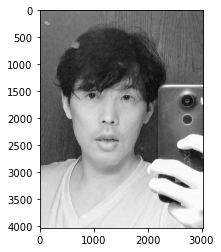

```python
img_red = img[:, :, 0]
plt.imshow(img_red, 'gray')
```

For most of the time in data science (especially in neural network), having a row and a column index of an image data is degarded as redundant. Thus we often reshape the image array into a vector form of RGB values,

```python
img_vector = img.reshape(img.shape[0]*img.shape[1], img.shape[2])
plt.imshow(img_vector.reshape(img.shape[0], img.shape[1], img.shape[2]))
```

[output not shown]

## Using Keras preprocessing.image

Keras offers many preprocessing tools, and Python Image Library (PIL) is integrated in Keras. PIL loads an image as a PIL image file rather than as a numpy array, so we have to use the image.img_to_array() function to convert the loaded image into a numpy array. Despite the inconvenience, PIL offers many useful functions to apply basic transformation to the image.

```python
# Opening an image in Keras
from keras.preprocessing import image
import matplotlib.pyplot as plt

# Load the raw image file
img = image.load_img('images/sugil.jpg')
plt.imshow(img)
type(img)
```

[output not shown]

```
PIL.JpegImagePlugin.JpegImageFile
```

Here's how to resize the image.

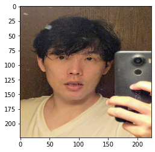

```python
img_square = image.load_img('images/sugil.jpg', target_size = (224, 224))
plt.imshow(img_square)
```

Finally, here is how to convert a PIL image data to a numpy array.

```python
x = image.img_to_array(img)
print(x)
print(type(x))
```

```
[[[110. 101.  84.]
  [110. 101.  84.]
  [111. 102.  85.]
  ...
  [ 84.  77.  59.]
  [ 84.  77.  59.]
  [ 83.  76.  58.]]

 [[110. 101.  84.]
  [110. 101.  84.]
  [111. 102.  85.]
  ...
  [ 86.  79.  61.]
  [ 85.  78.  60.]
  [ 85.  78.  60.]]

 [[110. 101.  84.]
  [110. 101.  84.]
  [111. 102.  85.]
  ...
  [ 84.  77.  59.]
  [ 83.  76.  58.]
  [ 83.  76.  58.]]

 ...

 [[222. 197. 157.]
  [222. 197. 157.]
  [221. 196. 156.]
  ...
  [197. 146. 103.]
  [197. 146. 103.]
  [197. 146. 103.]]

 [[221. 196. 156.]
  [221. 196. 156.]
  [221. 196. 156.]
  ...
  [197. 146. 103.]
  [197. 146. 103.]
  [197. 146. 103.]]

 [[221. 196. 156.]
  [221. 196. 156.]
  [220. 195. 155.]
  ...
  [197. 146. 103.]
  [197. 146. 103.]
  [197. 146. 103.]]]
<class 'numpy.ndarray'>
```

The source code can be found here.

Last edited: 2020/9/18